# Yelloweye Rockfish

*Sebastes ruberrimus*

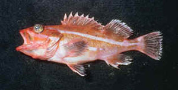

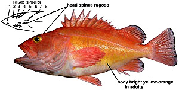

**Body color:** Red on back, bright orange-yellow on sides, most fins w/ black on tips. Young <28 cm red w/ whitish stripe along lateral line, another shorter stripe between lateral line and belly surface, fins w/ blackened tips. (See above photo.)

**Peritoneum color:** light **Shape between eyes:** concave

**Counts:** D:XIII,13-16, Ar:5-8, P1:18-20, GR:25-30, LLp:39-46, LLs:45-50, V:26

**Occurence:** Aleutian Islands - Baja California

**Depth:** 50-475 meters **Size:** 91 cm **Species code:** 30470

**Similar species:**

- *Canary rockfish* - body mottled gray dorsally w/ orange; anal fin pointed w/ strong anterior slant (rounded w/ posterior slant in Yelloweye RF)
- *Vermilion rockfish* - body mottled gray dorsally w/ red; anal fin pointed w/ strong anterior slant (rounded w/ posterior slant in Yelloweye RF)
- *Rougheye rockfish, Shortraker rockfish, and Blackgill rockfish* - body red w/ various dark mottling; 0-8 spines below eye

Back to Group

**Corrections:** If you see mistakes or want to suggest changes, please create an [issue](https://github.com/zoyafuso-NOAA/RACE_Survey_App/issues) on the source repository or

*reach out to Liz Dawson (Liz.Dawson AT noaa.gov).*